# Ex. 05-1: Intersecting ATAC-seq with GO database

## 1. Group ATAC peaks based on their dynamic accessibility changes

We characterized different clusters of dynamically regulated chromatin loci by ATAC-seq.

> Can you give a descriptive label to each cluster of ATAC peaks?

Given the patterns of varying chromatin accessibility in each peak cluster (see figure), we can merge and label clusters as follows:

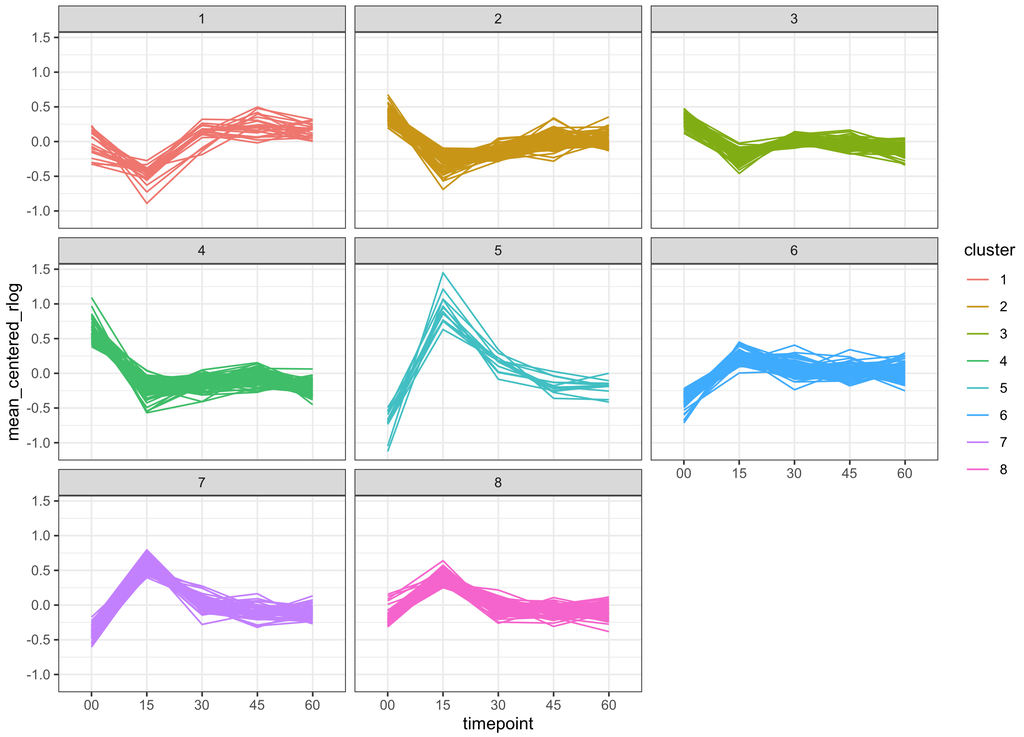

```r
library(tidyverse)
ATAC_peaks <- readRDS("Share/day04/ATAC_peaks_with_clusters.rds")
table(ATAC_peaks$cluster)
```

```
##
##    0    1    2    3    4    5    6    7    8
## 6040   22   80   68   80   13   82   50   78
```

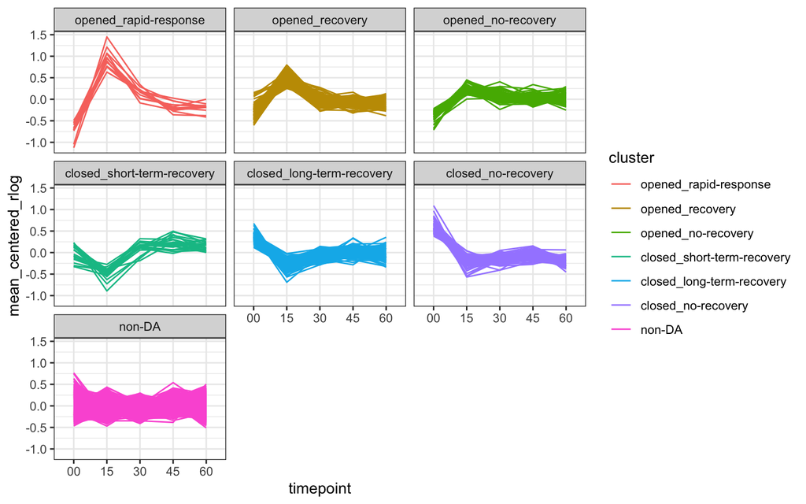

```r
cluster_names <- factor(c(
    "0" = "non-DA",
    "1" = "closed_short-term-recovery",
    "2" = "closed_long-term-recovery",
    "3" = "closed_long-term-recovery",
    "4" = "closed_no-recovery",
    "5" = "opened_rapid-response",
    "6" = "opened_no-recovery",
    "7" = "opened_recovery",
    "8" = "opened_recovery"
), levels = c(
    "opened_rapid-response", "opened_recovery", "opened_no-recovery",
    "closed_short-term-recovery", "closed_long-term-recovery", "closed_no-recovery",
    "non-DA")
)
ATAC_peaks$annot <- cluster_names[as.character(ATAC_peaks$cluster)]
saveRDS(ATAC_peaks, 'ATAC_peaks_with_annots.rds')
#
norm_rlogs <- mcols(ATAC_peaks)[, grepl('rlog_', colnames(mcols(ATAC_peaks)))] %>%
    apply(1, function(row) {row - mean(row)}) %>%
    t() %>%
    as_tibble() %>%
    mutate(locus = factor(ATAC_peaks$peakID)) %>%
    mutate(cluster = factor(ATAC_peaks$annot)) %>%
    gather('timepoint', 'mean_centered_rlog', -locus, -cluster) %>%
    group_by(cluster) %>%
    mutate(timepoint = gsub('rlog_', '', timepoint))
p <- ggplot(norm_rlogs, aes(x = timepoint, y = mean_centered_rlog, fill = cluster, group = locus, col = cluster)) +
    geom_line() +
    theme_bw() +
    facet_wrap(~cluster)
p
```

## 2. Gene Ontology analyses

Based on previous labelling, there are 3 different groups of chromatin loci which are characterized by an increase of accessibility following osmotic stress.

> Can you investigate the gene ontology of genes close to the chromatin loci in the `opened_recovery` cluster?

```r
clusters_TSSs <- lapply(
    levels(ATAC_peaks$annot),
    function(annot) {
        unique(ATAC_peaks$associated_gene[ATAC_peaks$annot == annot])
    }
) %>% setNames(levels(ATAC_peaks$annot))
lengths(clusters_TSSs)
```

```
##      opened_rapid-response            opened_recovery
##                         13                        118
##         opened_no-recovery closed_short-term-recovery
##                         82                         21
##  closed_long-term-recovery         closed_no-recovery
##                        139                         75
##                     non-DA
##                       4598
```

```r
go_opened_recovery <- gprofiler2::gost(clusters_TSSs[["opened_recovery"]], organism = 'scerevisiae')
go_opened_recovery$result
```

```
## # A tibble: 14 x 14
##    query significant p_value term_size query_size intersection_si… precision
##    <chr> <lgl>         <dbl>     <int>      <int>            <int>     <dbl>
##  1 quer… TRUE        1.44e-4       265         93               19    0.204
##  2 quer… TRUE        1.11e-2       203         93               14    0.151
##  3 quer… TRUE        2.36e-2       162         93               12    0.129
##  4 quer… TRUE        1.13e-3        13         35                4    0.114
##  5 quer… TRUE        3.81e-3        32         35                5    0.143
##  6 quer… TRUE        9.05e-3         9         35                3    0.0857
##  7 quer… TRUE        1.08e-2       767         35               23    0.657
##  8 quer… TRUE        1.27e-2        41         35                5    0.143
##  9 quer… TRUE        3.70e-2        14         35                3    0.0857
## 10 quer… TRUE        6.02e-6      2022        118               64    0.542
## 11 quer… TRUE        1.67e-2       464        118               20    0.169
## 12 quer… TRUE        1.80e-3         5         20                3    0.15
## 13 quer… TRUE        2.32e-2        79         20                7    0.35
## 14 quer… TRUE        2.53e-2         3         20                2    0.1
## # … with 7 more variables: recall <dbl>, term_id <chr>, source <chr>,
## #   term_name <chr>, effective_domain_size <int>, source_order <int>,
## #   parents <list>
```

> Can you perform the same operation for all the clusters?

```r
go_clusters <- lapply(
    levels(ATAC_peaks$annot),
    function(annot) {
        go_results <- gprofiler2::gost(clusters_TSSs[[annot]], organism = 'scerevisiae')$result
        go_results$annot <- annot
        return(go_results)
    }
) %>%
    do.call(rbind, .)
go_clusters
```

```
## # A tibble: 122 x 15
##    query significant p_value term_size query_size intersection_si… precision
##    <chr> <lgl>         <dbl>     <int>      <int>            <int>     <dbl>
##  1 quer… TRUE         0.0500         1          1                1       1
##  2 quer… TRUE         0.0500         1          1                1       1
##  3 quer… TRUE         0.0500         1          1                1       1
##  4 quer… TRUE         0.0500         1          1                1       1
##  5 quer… TRUE         0.0500         1          1                1       1
##  6 quer… TRUE         0.0500         1          1                1       1
##  7 quer… TRUE         0.0500         1          1                1       1
##  8 quer… TRUE         0.0500         1          1                1       1
##  9 quer… TRUE         0.0500         1          1                1       1
## 10 quer… TRUE         0.0429         6          2                1       0.5
## # … with 112 more rows, and 8 more variables: recall <dbl>, term_id <chr>,
## #   source <chr>, term_name <chr>, effective_domain_size <int>,
## #   source_order <int>, parents <list>, annot <chr>
```

```r
table(go_clusters$annot)
```

```
##
##  closed_long-term-recovery         closed_no-recovery
##                         32                         44
## closed_short-term-recovery                     non-DA
##                          4                         13
##         opened_no-recovery      opened_rapid-response
##                          3                         12
##            opened_recovery
##                         14
```

```r
go_clusters %>% filter(annot == "opened_recovery")
```

```
## # A tibble: 14 x 15
##    query significant p_value term_size query_size intersection_si… precision
##    <chr> <lgl>         <dbl>     <int>      <int>            <int>     <dbl>
##  1 quer… TRUE        1.44e-4       265         93               19    0.204
##  2 quer… TRUE        1.11e-2       203         93               14    0.151
##  3 quer… TRUE        2.36e-2       162         93               12    0.129
##  4 quer… TRUE        1.13e-3        13         35                4    0.114
##  5 quer… TRUE        3.81e-3        32         35                5    0.143
##  6 quer… TRUE        9.05e-3         9         35                3    0.0857
##  7 quer… TRUE        1.08e-2       767         35               23    0.657
##  8 quer… TRUE        1.27e-2        41         35                5    0.143
##  9 quer… TRUE        3.70e-2        14         35                3    0.0857
## 10 quer… TRUE        6.02e-6      2022        118               64    0.542
## 11 quer… TRUE        1.67e-2       464        118               20    0.169
## 12 quer… TRUE        1.80e-3         5         20                3    0.15
## 13 quer… TRUE        2.32e-2        79         20                7    0.35
## 14 quer… TRUE        2.53e-2         3         20                2    0.1
## # … with 8 more variables: recall <dbl>, term_id <chr>, source <chr>,
## #   term_name <chr>, effective_domain_size <int>, source_order <int>,
## #   parents <list>, annot <chr>
```

```r
go_clusters %>% filter(annot == "opened_no-recovery")
```

```
## # A tibble: 3 x 15
##   query significant p_value term_size query_size intersection_si… precision
##   <chr> <lgl>         <dbl>     <int>      <int>            <int>     <dbl>
## 1 quer… TRUE        6.01e-4        28         29                5     0.172
## 2 quer… TRUE        4.05e-2      1097         82               26     0.317
## 3 quer… TRUE        1.25e-2        12         12                3     0.25
## # … with 8 more variables: recall <dbl>, term_id <chr>, source <chr>,
## #   term_name <chr>, effective_domain_size <int>, source_order <int>,
## #   parents <list>, annot <chr>
```

```r
go_clusters %>% filter(annot == "closed_short-term-recovery")
```

```
## # A tibble: 4 x 15
##   query significant p_value term_size query_size intersection_si… precision
##   <chr> <lgl>         <dbl>     <int>      <int>            <int>     <dbl>
## 1 quer… TRUE        0.00902       968         18               12     0.667
## 2 quer… TRUE        0.0216        258         19                6     0.316
## 3 quer… TRUE        0.0217        160         19                5     0.263
## 4 quer… TRUE        0.0312        187         11                5     0.455
## # … with 8 more variables: recall <dbl>, term_id <chr>, source <chr>,
## #   term_name <chr>, effective_domain_size <int>, source_order <int>,
## #   parents <list>, annot <chr>
```

```r
go_clusters %>% filter(annot == "closed_no-recovery")
```

```
## # A tibble: 44 x 15
##    query significant p_value term_size query_size intersection_si… precision
##    <chr> <lgl>         <dbl>     <int>      <int>            <int>     <dbl>
##  1 quer… TRUE        0.00217        29         41                5     0.122
##  2 quer… TRUE        0.00217        29         41                5     0.122
##  3 quer… TRUE        0.00259        30         41                5     0.122
##  4 quer… TRUE        0.00307        31         41                5     0.122
##  5 quer… TRUE        0.00307        31         41                5     0.122
##  6 quer… TRUE        0.00307        31         41                5     0.122
##  7 quer… TRUE        0.00307        31         41                5     0.122
##  8 quer… TRUE        0.00361        32         41                5     0.122
##  9 quer… TRUE        0.00361        32         41                5     0.122
## 10 quer… TRUE        0.00361        32         41                5     0.122
## # … with 34 more rows, and 8 more variables: recall <dbl>, term_id <chr>,
## #   source <chr>, term_name <chr>, effective_domain_size <int>,
## #   source_order <int>, parents <list>, annot <chr>
```

```r
go_clusters %>% filter(annot == "closed_long-term-recovery")
```

```
## # A tibble: 32 x 15
##    query significant p_value term_size query_size intersection_si… precision
##    <chr> <lgl>         <dbl>     <int>      <int>            <int>     <dbl>
##  1 quer… TRUE        7.43e-5        43        101                9    0.0891
##  2 quer… TRUE        3.26e-4       119        101               13    0.129
##  3 quer… TRUE        6.04e-4       350        101               22    0.218
##  4 quer… TRUE        6.32e-4       106        101               12    0.119
##  5 quer… TRUE        6.35e-4       126        101               13    0.129
##  6 quer… TRUE        9.45e-4       110        101               12    0.119
##  7 quer… TRUE        1.44e-3         6        101                4    0.0396
##  8 quer… TRUE        1.44e-3         6        101                4    0.0396
##  9 quer… TRUE        4.74e-3       128        101               12    0.119
## 10 quer… TRUE        6.53e-3         8        101                4    0.0396
## # … with 22 more rows, and 8 more variables: recall <dbl>, term_id <chr>,
## #   source <chr>, term_name <chr>, effective_domain_size <int>,
## #   source_order <int>, parents <list>, annot <chr>
```

## 2. Gene Set Enrichment Analysis

GEAS is an approach *kind of* similar to that of GO enrichment analysis, with one big difference. In GO enrichment analyses, one specifies a **gene set**, and Gene Ontology terms statistically enriched within this set of genes are retrieved. In GEAS analyses, a list of genes (usually all genes in the genome) are ranked by a value (usually the fold-change between 2 conditions). Then, for a given gene set of interest (e.g. genes associated with a specific Gene Ontology term), the position of these genes is retrieved in the initial list of ranked genes. Based on their position, an enrichment score can be computed, incidicating whether the genes from the set of interest are predominently found at the top or at the bottom of the ranked list.

> Can we perform GSEA in our list of ATAC peaks?

> Can you find an alternative that would allow you to use the list of ATAC peaks for GSEA?

> Import the `Gudin2019.txt` table and rank the genes based on their expression fold-change between 10min of osmotic stress and no treatment

```r
df <- read.table('Share/day05/Gutin2019.txt', sep = '\t', header = TRUE) %>%
    dplyr::rename('gene' = 'X') %>%
    mutate(ratio = WT.t10/WT.t00) %>%
    filter(!is.infinite(ratio) & !is.na(ratio)) %>%
    arrange(desc(ratio))
```

> Perform GSEA on that ranked list. `gseGO()` is function to perform GSEA using Gene Ontology sets and is included in the awesome `clusterProfiler` package.

```r
list_genes <- df$ratio
names(list_genes) <- df$gene
gsea_results <- clusterProfiler::gseGO(
    list_genes,
    keyType = "ENSEMBL",
    OrgDb = org.Sc.sgd.db::org.Sc.sgd.db,
    verbose = TRUE
)
```

```
## preparing geneSet collections...
```

```
## GSEA analysis...
```

```
## leading edge analysis...
```

```
## done...
```

```r
gsea_results@result[, 1:8] %>% arrange(desc(NES)) %>% head(20)
```

```
## # A tibble: 9 x 8
##   ID     Description      setSize enrichmentScore   NES  pvalue p.adjust qvalues
##   <chr>  <chr>              <int>           <dbl> <dbl>   <dbl>    <dbl>   <dbl>
## 1 GO:00… glycogen biosyn…      23           0.806  2.31 2.10e-4  0.0449  0.0434
## 2 GO:00… cellular carboh…      56           0.720  2.30 7.43e-6  0.00693 0.00671
## 3 GO:00… monocarboxylic …      27           0.777  2.28 6.36e-5  0.0297  0.0287
## 4 GO:00… energy reserve …      34           0.736  2.24 9.55e-5  0.0345  0.0334
## 5 GO:00… response to osm…      85           0.613  2.02 1.11e-4  0.0345  0.0334
## 6 GO:00… carbohydrate bi…      87           0.592  1.95 2.17e-4  0.0449  0.0434
## 7 GO:00… cellular carboh…     153           0.552  1.89 2.11e-5  0.0131  0.0127
## 8 GO:00… carbohydrate me…     238           0.503  1.75 6.95e-6  0.00693 0.00671
## 9 GO:00… response to abi…     185           0.497  1.71 1.37e-4  0.0365  0.0354
```

## Conclusions

> Conclude on the relative usefulness of GO enrichment analysis / GSEA